# Real example: analysis of DO events

Constantino A. García

In this vignette, a paleoclimate record from the Greenland ice cores is studied. Among other interesting phenomena, these records permit to identify the abrupt climate changes that occurred during the last glacial period, which are usually referred to as Dansgaard-Oeschger (DO) events. Specifically, a $\delta^{18}\text{O}$ record from the North Greenland Ice Core Project ([NGRIP](http://www.iceandclimate.nbi.ku.dk/data/)) is used. The $\delta^{18}\text{O}$ is a measure of the ratio of the stable isotopes oxygen-18 and oxygen-16 and it is commonly used to estimate the temperature at the time that each small section of the ice core was formed. The data is already preloaded with `voila`:

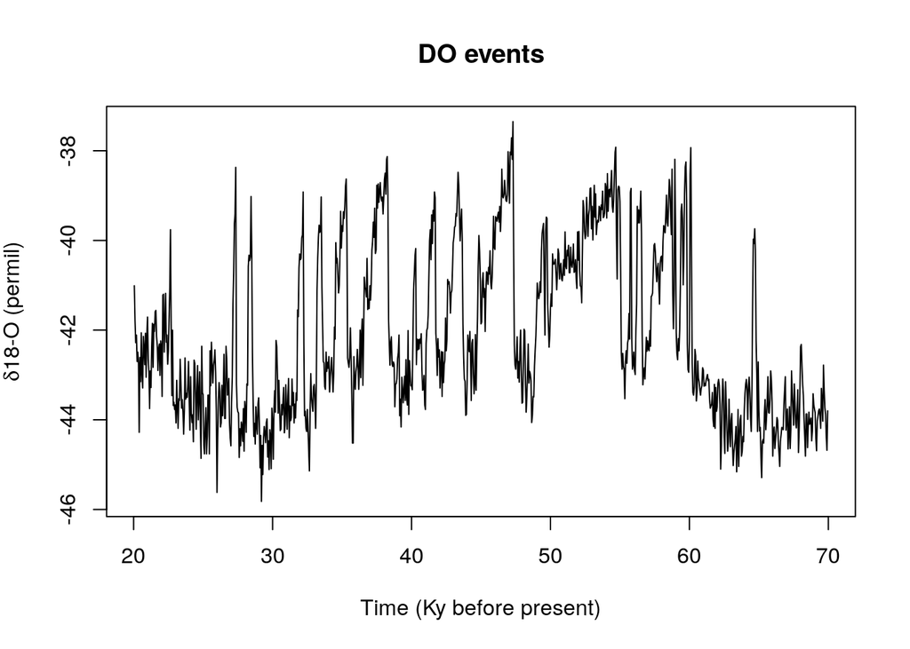

```r
library('voila')
plot(do_events, main = "DO events",
     xlab = "Time (Ky before present)",
     ylab = expression(paste(delta,'18-O (permil)')))
```

For the sake of simplicity (and convergence speed), we shall use 10 pseudo-inputs and two rational quadratic kernels, although these selections are not optimal (see reference [1] for further details). The following snippet performs the inference after specifying some initial values for the pseudo-inputs and the kernels.

```r
# sampling period in Ky before present
samplingPeriod = deltat(do_events)
# voila uses data in matrix format
do_events = matrix(do_events, ncol = 1)
# Spread initial pseudo-inputs along the support of do_events
noInducingPoints = 10
pseudoInputs = matrix(seq(min(do_events), max(do_events), len = noInducingPoints),
                      ncol = 1)
# small value to regularize covariance matrices
epsilon = 1e-5
# Create the kernels defining the behaviour of the gaussian processes.
# We shall create two Rational Quadratic Kernel for both the drift and
# diffusion with some initial values for the hyperparameters. These
# hyperparameters will be optimized during the inference process.
driftKer = sde_kernel("rq_kernel",
                       list('amplitude' = 30, # huge amplitude: huge uncertainty
                            'alpha' = 2,
                            'lengthScales' = 2),
                      ncol(do_events), epsilon)
# Voila uses a log-normal prior to ensure the positiveness of the diffusion. The
# 'select_diffusion_parameters' function permits to select a proper amplitude for the
# kernel from our prior belief about the amplitude of the diffusion function. It also
# selects a mean value for the log-normal distribution (denoted with v)
diffParams = select_diffusion_parameters(do_events, samplingPeriod,
                                         priorOnSd = 30)
diffKer =  sde_kernel("rq_kernel",
                      list('amplitude' = diffParams$kernelAmplitude,
                           'alpha' = 1,
                           'lengthScales' = 2),
                      ncol(do_events), epsilon)

# Perform the variational inference (VI)
inference = sde_vi(1, do_events, samplingPeriod, pseudoInputs,
                   driftKer, diffKer, diffParams$v,
                   maxIterations = 1000)
```

The following snippet plots the resulting estimates of the drift and diffusion functions.

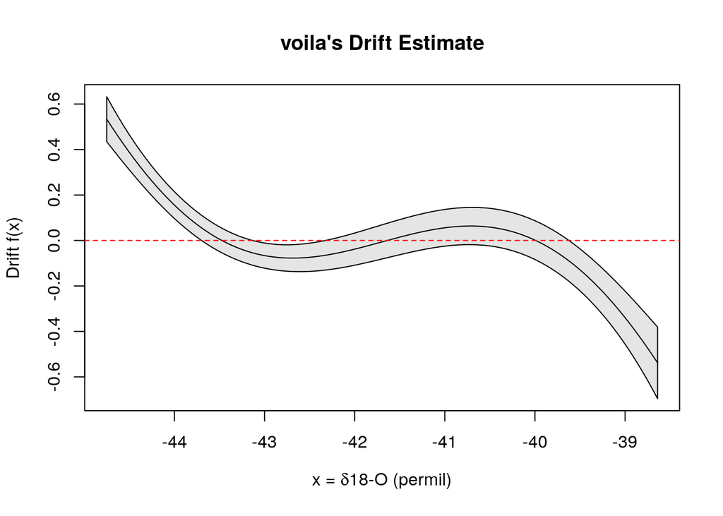

```r
# Get the estimations for the drift and diffusion
predictionSupport = matrix(seq(quantile(do_events,0.025),
                               quantile(do_events,0.975), len = 100),
                           ncol = 1)
driftPred = predict(inference$drift, predictionSupport)
# the diffusion uses a log-normal gaussian process, so we must specify log = TRUE
diffPred = predict(inference$diff, predictionSupport, log = TRUE)

# Plot drift
plot(driftPred, main = "voila's Drift Estimate",
     xlab = expression(paste("x = ", delta,'18-O (permil)')),
     ylab = "Drift f(x)")
abline(h = 0, lty = 2, col = 2)
```

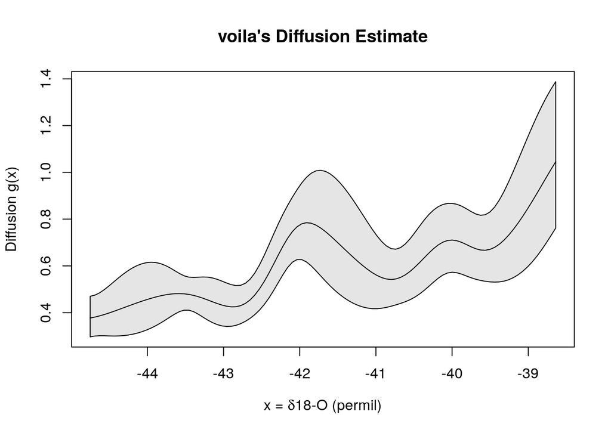

```r
# Plot diffusion
plot(diffPred, main = "voila's Diffusion Estimate",
     xlab = expression(paste("x = ", delta,'18-O (permil)')),
     ylab = "Diffusion g(x)")
```

### References

This example is discussed in detail in the paper:

> [1] García, C.A., Otero, A., Félix, P., Presedo, J. & Márquez D.G., (2017). **Non-parametric Estimation of Stochastic Differential Equations with Sparse Gaussian Processes** *(under review)*, [preprint](https://arxiv.org/abs/1704.04375).